# FML A4

##### B.Interpret the clusters with respect to the numerical variables used in forming the clusters.

```r
PC_Cluster <- Pharma_data[,(10:12)]%>% mutate(clusters = Best_cluster$cluster)%>% arrange(clusters, .desc = TRUE)
```

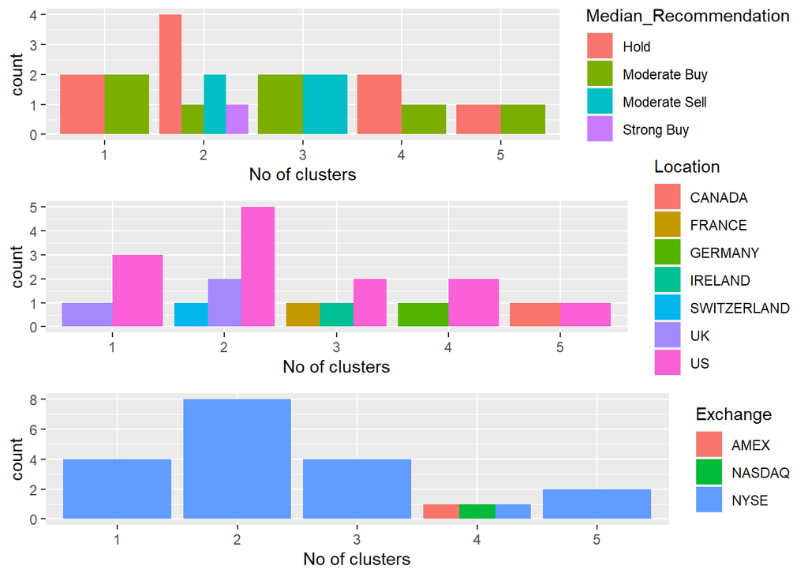

```r
library(dplyr)
plot_Med<-ggplot(PC_Cluster, mapping = aes(factor(clusters), fill=Median_Recommendation))+geom_bar(position = 'dodge')+labs(x ='No of clusters')

plot_Loc<- ggplot(PC_Cluster, mapping = aes(factor(clusters),fill = Location))+geom_bar(position = 'dodge')+labs(x ='No of clusters')

plot_Ex<- ggplot(PC_Cluster, mapping = aes(factor(clusters),fill = Exchange))+geom_bar(position = 'dodge')+labs(x ='No of clusters')

grid.arrange(plot_Med, plot_Loc, plot_Ex)
```

- **Cluster 1** It has equal hold and moderate buy for the locations UK and US with NYSE as exchange.
- **Cluster 2** It has hold, moderate buy, moderate sell and strong buy of which “Hold has more weightage in the locations UK, US and Switzerland with NYSE as exchange.
- **Cluster 3** It has moderate buy and sell in the locations in France,Ireland and US with NYSE as exchange.
- **Cluster 4** It has more hold followed by moderate buy for the locations Germany and US with AMEX, NASDAQ and NYSE as exchange.
- **Cluster 5** It has equal hold and moderate for Canada and US with NYSE as exchange.

##### D. Provide an appropriate name for each cluster using any or all of the variables in the dataset.

Cluster 1 - Equal Hold-Buy Cluster 2 - High Hold Cluster 3 - Buy-Sell Cluster 4 - More Hold-Buy Cluster 5 - Low Equal Hold-Buy